# TP6- Dellouve et Gazzo

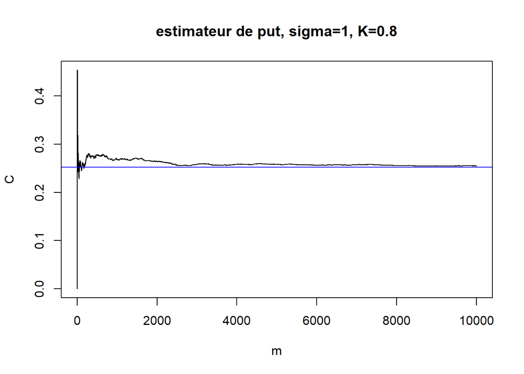

```r
plot(m,C,type='l',main="estimateur de put, sigma=1, K=0.8")
abline(put_niveau,0,col='blue') # on converge bien vers call
```

```r
var(B) #variance de Ym
```

```
## [1] 0.001151113
```

```r
var(C) #variance de Zm
```

```
## [1] 6.151431e-05
```

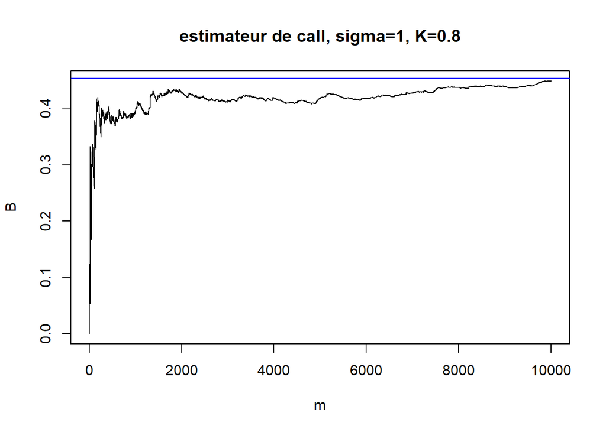

```r
#test2
A<-rcallput(10000,1,0.8)
B<-cumsum(A[,1])/m # Ym barre
C<-cumsum(A[,2])/m # Zm barre
call_niveau<-call(1,0.8)
put_niveau<-put(1,0.8)

plot(m,B,type='l',main="estimateur de call, sigma=1, K=0.8")
abline(call_niveau,0,col='blue') # on converge bien vers call
```

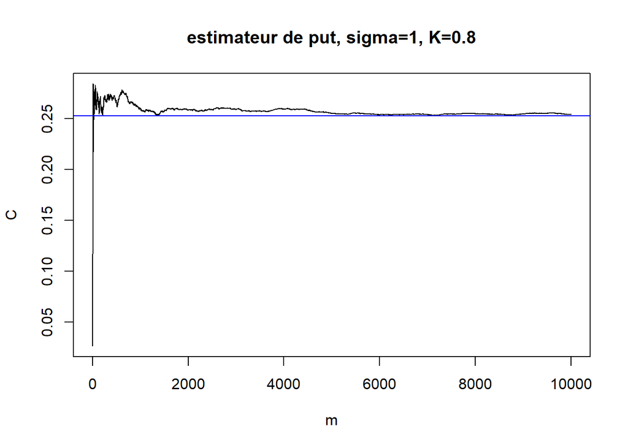

```r
plot(m,C,type='l',main="estimateur de put, sigma=1, K=0.8")
abline(put_niveau,0,col='blue') # on converge bien vers call
```

```r
var(B) #variance de Ym
```

```
## [1] 0.000718675
```

```r
var(C) #variance de Zm
```

```
## [1] 4.264427e-05
```

Dans tout les cas, les estimateurs convergent bien vers la valeur attendue.

On ramarque que la variance de $\bar Y_m$ est plus élevé que celle de $\bar Z_m$, ce qui est assez visible pour le cas $\sigma=3$. Il vaut mieux calculer la fonction qui donne la plus petite variance pour avoir une meilleur convergence. Ici il vaut donc mieux calculer la fonction $\texttt{put}$.

$Y=0$ si on a :

$$e^{\sigma X - \frac{\sigma^2}{2}}-K \le 0 \Leftrightarrow e^{\sigma X - \frac{\sigma^2}{2}} \le K \Leftrightarrow \sigma X - \frac{\sigma^2}{2} \le ln(K) = 0,\text{ car } K=1,$$

$$X - \frac{\sigma}{2}\le0 \Leftrightarrow X\le\frac{\sigma}{2}.$$

Et $Z=0$ si on a:

$$K-e^{\sigma X - \frac{\sigma^2}{2}}\le0 \Leftrightarrow K \le e^{\sigma X - \frac{\sigma^2}{2}} \Leftrightarrow 0=ln(K) \le \sigma X - \frac{\sigma^2}{2}, \text{ car } K=1,$$

$$0 \le \sigma X - \frac{\sigma^2}{2} \Leftrightarrow X \ge \frac{\sigma}{2}.$$

On peut expliquer les observatons sur la variance par le fait que $X$ est centrée est suit une loi normale, on a donc plus de termes proche de $0$. Ainsi, sachant que chaque terme est susceptible d’augmenter la variance, on trouve que $\bar Y_m$ a une plus grande variance.

## Exercice 4

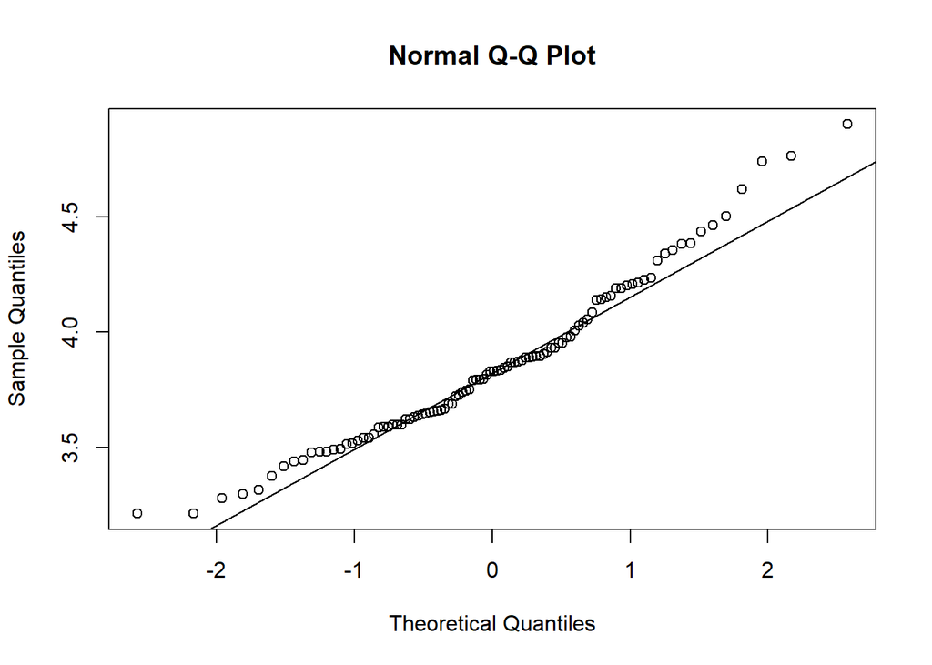

```r
#Q1 Q2 Q3
n<-100
m<-1000
Y<-matrix(ncol=n,nrow=m)
Z<-matrix(ncol=n,nrow=m)
for (i in 1:n)
{
  A<-rcallput(m,1,1)
  Y[,i]=A[,1]
  Z[,i]=A[,2]
}

vect_y<-colSums(Y)/n
vect_z<-colSums(Z)/n

#Q4
qqnorm(vect_y)
qqline(vect_y)
```

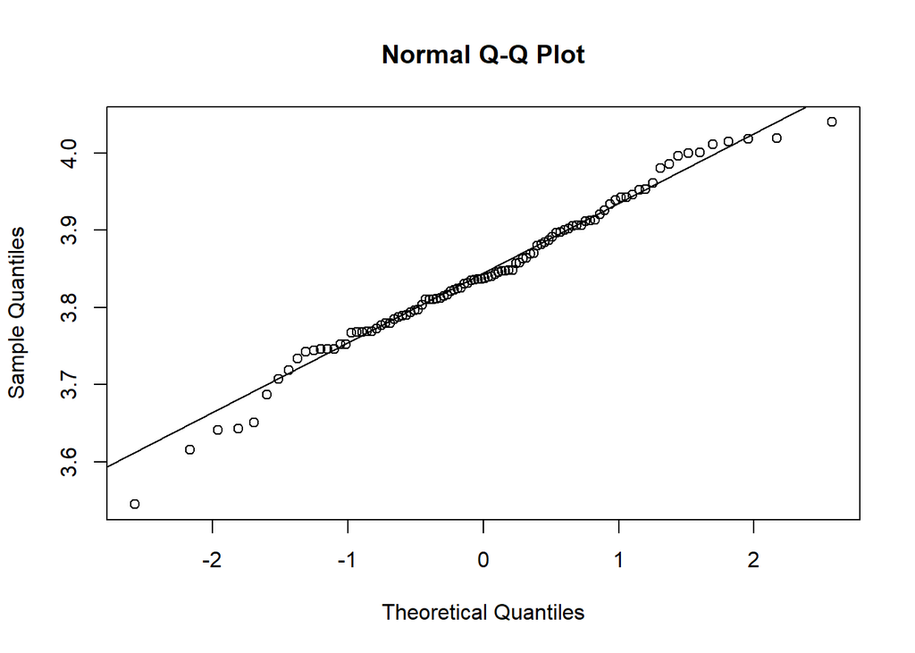

```r
qqnorm(vect_z)
qqline(vect_z)
```

$\texttt{qqplot}$ et $\texttt{qqnorm}$ donne le rapport quantile-quantile entre l’échantillon et la loi normale adaptée.

Plus la pente est raide, plus la variance est grande. Ici, on observe que la variance de $Y$ est plus grande que celle de $Z$. C’était prévisible, car théoriquement $Var(Y) > Var(Z)$.

L’intersection à l’origine correspond à la moyenne.

On remarque que les échantillons semblent proches d’une loi normale adaptée.

On trace donc les histogrammes avec la densité d’une loi normale adaptée à titre de comparaison:

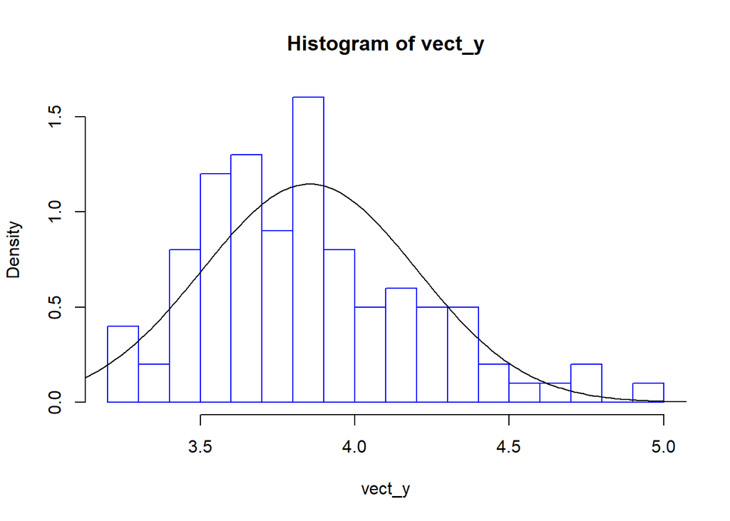

```r
#Q5-6
I<-seq(2,6,0.01)

hist(vect_y,20,freq=FALSE,border='blue')
lines(I,dnorm(I,mean=mean(vect_y),sd=sqrt(var(vect_y))))
```

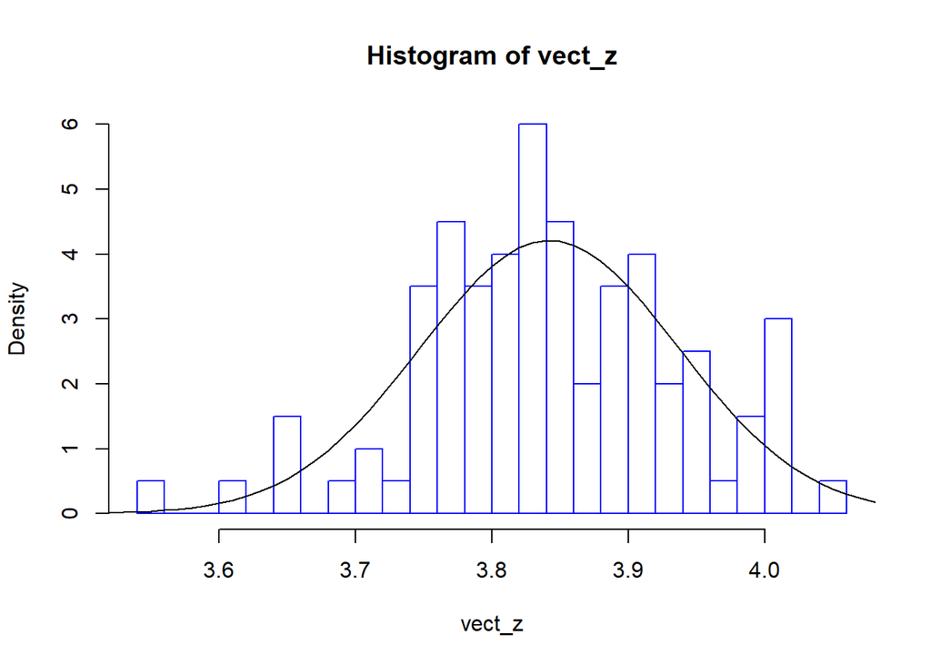

```r
#Q7

hist(vect_z,20,freq=FALSE,border='blue')
lines(I,dnorm(I,mean=mean(vect_z),sd=sqrt(var(vect_z))))
```

On observe une similarité.

```r
#Q8

n<-100
m<-100
Y<-matrix(ncol=n,nrow=m)
Z<-matrix(ncol=n,nrow=m)
for (i in 1:n)
{
  A<-rcallput(m,1,1)
  Y[,i]=A[,1]
  Z[,i]=A[,2]
}


vect_y<-colSums(Y)/n
vect_z<-colSums(Z)/n
```

On obtient la moyenne des deux estimateurs :

```r
mean(vect_y)
```

```
## [1] 0.3643599
```

```r
mean(vect_z)
```

```
## [1] 0.3863631
```

On obtient l’intervalle de confiance suivant :

```r
#IC y
int_conf_call<-c(mean(vect_y)-1.96*(sqrt(var(vect_y)))/sqrt(100),mean(vect_y)+1.96*(sqrt(var(vect_y)))/sqrt(100))
int_conf_call
```

```
## [1] 0.3429758 0.3857441
```

```r
#IC z
int_conf_put<-c(mean(vect_z)-1.96*(sqrt(var(vect_z)))/sqrt(100),mean(vect_z)+1.96*(sqrt(var(vect_z)))/sqrt(100))
int_conf_put
```

```
## [1] 0.3799764 0.3927499
```

On a bien un intervalle de confiance de taille inférieure pour $\texttt{put}$.

## Exercice 5

```r
#Q1

I<-function(X)
{
  n<-length(X)
  int_conf<-c(mean(X)-1.96*(sqrt(var(X)))/sqrt(n),mean(X)+1.96*(sqrt(var(X)))/sqrt(n))
  return(int_conf)
}
```

# Question 2

On obtient l’intervalle de confiance suivant :

```r
A<-rcallput(1000,1,1)
vect_y<-A[,1]
I(vect_y)
```

```
## [1] 0.3446225 0.5305586
```

# Question 3

On utilise la relation liant $\texttt{call}$ et $\texttt{put}$ donné a l’exercice 1, qui pour notre cas donne $C=P$ (car $C-P=0$). On va donc calculer l’intervalle de confiance de l’estimateur de $\texttt{put}$, qui a une variance inférieure à l’estimateur de $\texttt{call}$. Grâce à la relation citée, on aura également l’intervalle de confiance de $\texttt{call}$. On trouve l’intervalle de confiance suivant :

```r
A<-rcallput(1000,1,1)
vect_z<-A[,2]
I(vect_z)
```

```
## [1] 0.3498384 0.3909446
```

On obtient bien un intervalle de confiance de taille inférieure.

# Question 4

On trouve l’intervalle de confiance suivant :

```r
#Q4

V<-rexp(1000,1./2) #1000 réalsation de V

K=1
sigma=1

q1<-K-exp(sigma*sqrt(V)-sigma**2/2)
q2<-K-exp(-sigma*sqrt(V)-sigma**2/2)
q<-q1*(q1>0)+q2*(q2>0)
I(q/sqrt(2*pi*V)) #meilleur que q1
```

```
## [1] 0.3350805 0.3784684
```

La taille de l’intervalle de confiance ne diminue pas, il n’est pas meilleur.

# Question 5

On dérive la fonction $f(x)=K-e^{\sigma X - \frac{\sigma^2}{2}}$ pour étudier sa monotonie.

$f'(x)=-\sigma e^{\sigma X - \frac{\sigma^2}{2}} < 0$, ainsi $f$ est décroissante.

# Question 6

On peut prendre $T(X)=-X$ car $X$ est symétrique.

# Question 7

On utilise l’estimateur $e_2=\frac{1}{2n}\sum_{i=1}^{n}\left[g(X_i)+g(T(X_i))\right]$

# Question 8

On code $e_2$ et on obtient l’intervalle de confiance suivant :

```r
X<-rnorm(1000)
a<-K-exp(sigma*X-sigma^2/2)
a<-a*(a>0)
b<-K-exp(sigma*(-X)-sigma^2/2)
b<-b*(b>0)
e2<-(1/2000)*sum(a+b)
e2
```

```
## [1] 0.3808537
```

```r
I((1/2)*(a+b)) # meilleur qu'on a
```

```
## [1] 0.3783939 0.3833135
```

La taille de l’intervalle de confiance est plus petit que ce qu’on a obtenu précedemment, il est donc meilleur.